PT Komoditi Ria Kencana Exploratory Product Data Analysis Report Syabaruddin Malik 3/29/2021

# 1. Background

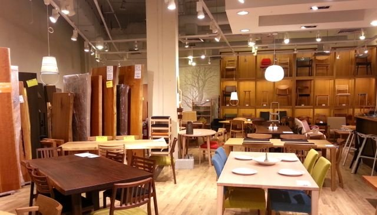

PT Komoditi Ria Kencana is a retail commodity trading company. The company have worldwide activities in the sourcing, transporting, storage, and financing of some commodities products to retail market. Their success is built upon knowledge of the market, reliability and independence

They strive to be a reliable and competitive partner, working to contribute to their customers’ and suppliers’ expansion and development

This report contains of explanatory product data analysis from PT Komoditi Ria Kencana including sales records data, P&L data and other detail data.

# 2. Exploratory Data

## 2.1 Data Inspection

Before we do explanatory data analysis, we need to inspect our data and do some cleanings if it is necessary.

Our first step is inputting the data.

```r
komoditi <- read.csv("data_input/retail.csv")
```

Our next step is inspecting the data.

First, we have to check the dimension of the data by using function dim().

```r
dim(komoditi)
```

```
## [1] 9994   15
```

The data has dimension as follows:

- 9994 rows. It means that the company had 9994 transactions from 2014 to 2017
- 15 columns. It means that the data had recorded 15 variables, from Order ID to Product details.

Now we will cross check the dimension by calling the first 6 data and the last 6 data by using function head() and tail()

```r
head(komoditi)
```

|  | Row.ID | Order.ID | Order.Date | Ship.Date | Ship.Mode | Customer.ID | Segment | Product.ID | Category | Sub.Category | Product.Name | Sales | Quantity | Discount | Profit |
| --- | --- | --- | --- | --- | --- | --- | --- | --- | --- | --- | --- | --- | --- | --- | --- |
| 1 | 1 | CA-2016-152156 | 11/8/16 | 11/11/16 | Second Class | CG-12520 | Consumer | FUR-BO-10001798 | Furniture | Bookcases | Bush Somerset Collection Bookcase | 261.9600 | 2 | 0.00 | 41.9136 |
| 2 | 2 | CA-2016-152156 | 11/8/16 | 11/11/16 | Second Class | CG-12520 | Consumer | FUR-CH-10000454 | Furniture | Chairs | Hon Deluxe Fabric Upholstered Stacking Chairs, Rounded Back | 731.9400 | 3 | 0.00 | 219.5820 |
| 3 | 3 | CA-2016-138688 | 6/12/16 | 6/16/16 | Second Class | DV-13045 | Corporate | OFF-LA-10000240 | Office Supplies | Labels | Self-Adhesive Address Labels for Typewriters by Universal | 14.6200 | 2 | 0.00 | 6.8714 |
| 4 | 4 | US-2015-108966 | 10/11/15 | 10/18/15 | Standard Class | SO-20335 | Consumer | FUR-TA-10000577 | Furniture | Tables | Bretford CR4500 Series Slim Rectangular Table | 957.5775 | 5 | 0.45 | -383.0310 |
| 5 | 5 | US-2015-108966 | 10/11/15 | 10/18/15 | Standard Class | SO-20335 | Consumer | OFF-ST-10000760 | Office Supplies | Storage | Eldon Fold 'N Roll Cart System | 22.3680 | 2 | 0.20 | 2.5164 |
| 6 | 6 | CA-2014-115812 | 6/9/14 | 6/14/14 | Standard Class | BH-11710 | Consumer | FUR-FU-10001487 | Furniture | Furnishings | Eldon Expressions Wood and Plastic Desk Accessories, Cherry Wood | 48.8600 | 7 | 0.00 | 14.1694 |

```r
tail(komoditi)
```

|  | Row.ID | Order.ID | Order.Date | Ship.Date | Ship.Mode | Customer.ID | Segment | Product.ID | Category | Sub.Category | Product.Name | Sales | Quantity | Discount | Profit |
| --- | --- | --- | --- | --- | --- | --- | --- | --- | --- | --- | --- | --- | --- | --- | --- |
| 9989 | 9989 | CA-2017-163629 | 11/17/17 | 11/21/17 | Standard Class | RA-19885 | Corporate | TEC-PH-10004006 | Technology | Phones | Panasonic KX - TS880B Telephone | 206.100 | 5 | 0.0 | 55.6470 |
| 9990 | 9990 | CA-2014-110422 | 1/21/14 | 1/23/14 | Second Class | TB-21400 | Consumer | FUR-FU-10001889 | Furniture | Furnishings | Ultra Door Pull Handle | 25.248 | 3 | 0.2 | 4.1028 |
| 9991 | 9991 | CA-2017-121258 | 2/26/17 | 3/3/17 | Standard Class | DB-13060 | Consumer | FUR-FU-10000747 | Furniture | Furnishings | Tenex B1-RE Series Chair Mats for Low Pile Carpets | 91.960 | 2 | 0.0 | 15.6332 |
| 9992 | 9992 | CA-2017-121258 | 2/26/17 | 3/3/17 | Standard Class | DB-13060 | Consumer | TEC-PH-10003645 | Technology | Phones | Aastra 57i VoIP phone | 258.576 | 2 | 0.2 | 19.3932 |
| 9993 | 9993 | CA-2017-121258 | 2/26/17 | 3/3/17 | Standard Class | DB-13060 | Consumer | OFF-PA-10004041 | Office Supplies | Paper | It's Hot Message Books with Stickers, 2 3/4" x 5" | 29.600 | 4 | 0.0 | 13.3200 |
| 9994 | 9994 | CA-2017-119914 | 5/4/17 | 5/9/17 | Second Class | CC-12220 | Consumer | OFF-AP-10002684 | Office Supplies | Appliances | Acco 7-Outlet Masterpiece Power Center, Wihtout Fax/Phone Line Protection | 243.160 | 2 | 0.0 | 72.9480 |

So the dimension is matched by using function dim() and head()/tail(). Great!

The next inspection is to make sure the columns name of the data to ease our explanatory data analysis.

```r
names(komoditi)
```

```
##  [1] "Row.ID"       "Order.ID"     "Order.Date"   "Ship.Date"    "Ship.Mode"
##  [6] "Customer.ID"  "Segment"      "Product.ID"   "Category"     "Sub.Category"
## [11] "Product.Name" "Sales"        "Quantity"     "Discount"     "Profit"
```

Each Collumns label is as follows: + “Row.ID”, “Order.ID”, “Order.Date”, “Ship.Date”, “Ship.Mode”, “Customer.ID”, “Segment”,“Product.ID”, “Category”, “Sub.Category”, “Product.Name”, “Sales”, “Quantity”, “Discount”, “Profit”

The last inspection is to check one by one the datatype of each columns. This inspection is needed to check if the datatype is in the correct form of the datatype required to do the explanatory data analysis. We use funcion str() to check the datatype of each columns.

```r
str(komoditi)
```

```
## 'data.frame':    9994 obs. of  15 variables:
##  $ Row.ID      : int  1 2 3 4 5 6 7 8 9 10 ...
##  $ Order.ID    : chr  "CA-2016-152156" "CA-2016-152156" "CA-2016-138688" "US-2015-108966" ...
##  $ Order.Date  : chr  "11/8/16" "11/8/16" "6/12/16" "10/11/15" ...
##  $ Ship.Date   : chr  "11/11/16" "11/11/16" "6/16/16" "10/18/15" ...
##  $ Ship.Mode   : chr  "Second Class" "Second Class" "Second Class" "Standard Class" ...
##  $ Customer.ID : chr  "CG-12520" "CG-12520" "DV-13045" "SO-20335" ...
##  $ Segment     : chr  "Consumer" "Consumer" "Corporate" "Consumer" ...
##  $ Product.ID  : chr  "FUR-BO-10001798" "FUR-CH-10000454" "OFF-LA-10000240" "FUR-TA-10000577" ...
##  $ Category    : chr  "Furniture" "Furniture" "Office Supplies" "Furniture" ...
##  $ Sub.Category: chr  "Bookcases" "Chairs" "Labels" "Tables" ...
##  $ Product.Name: chr  "Bush Somerset Collection Bookcase" "Hon Deluxe Fabric Upholstered Stacking Chairs, Rounded Back" "Self-Adhesive Address Labels for Typewriters by Universal" "Bretford CR4500 Series Slim Rectangular Table" ...
##  $ Sales       : num  262 731.9 14.6 957.6 22.4 ...
##  $ Quantity    : int  2 3 2 5 2 7 4 6 3 5 ...
##  $ Discount    : num  0 0 0 0.45 0.2 0 0 0.2 0.2 0 ...
##  $ Profit      : num  41.91 219.58 6.87 -383.03 2.52 ...
```

We found out that some of the columns are not in the correct datatype.

- Order Date and Ship Date columns should be in Datetime datatype
- Ship Mode, Segment, Category, and Sub.Category should be in Category/Factor datatype

In the next process (data cleansing and coertion), we will change the incorrect datatypes to the correct datatypes

## 2.2 Data Cleansing & Coertions

Following up the last chapter, we need to change some of the incorrect datatypes to the correct datatype.

```r
komoditi$Segment      <- as.factor(komoditi$Segment)
komoditi$Category     <- as.factor(komoditi$Category)
komoditi$Order.Date   <- as.Date(komoditi$Order.Date, "%m/%d/%y")
komoditi$Ship.Date    <- as.Date(komoditi$Ship.Date, "%m/%d/%y")
komoditi$Ship.Mode    <- as.factor(komoditi$Ship.Mode)
komoditi$Sub.Category <- as.factor(komoditi$Sub.Category)


str(komoditi)
```

```
## 'data.frame':    9994 obs. of  15 variables:
##  $ Row.ID      : int  1 2 3 4 5 6 7 8 9 10 ...
##  $ Order.ID    : chr  "CA-2016-152156" "CA-2016-152156" "CA-2016-138688" "US-2015-108966" ...
##  $ Order.Date  : Date, format: "2016-11-08" "2016-11-08" ...
##  $ Ship.Date   : Date, format: "2016-11-11" "2016-11-11" ...
##  $ Ship.Mode   : Factor w/ 4 levels "First Class",..: 3 3 3 4 4 4 4 4 4 4 ...
##  $ Customer.ID : chr  "CG-12520" "CG-12520" "DV-13045" "SO-20335" ...
##  $ Segment     : Factor w/ 3 levels "Consumer","Corporate",..: 1 1 2 1 1 1 1 1 1 1 ...
##  $ Product.ID  : chr  "FUR-BO-10001798" "FUR-CH-10000454" "OFF-LA-10000240" "FUR-TA-10000577" ...
##  $ Category    : Factor w/ 3 levels "Furniture","Office Supplies",..: 1 1 2 1 2 1 2 3 2 2 ...
##  $ Sub.Category: Factor w/ 17 levels "Accessories",..: 5 6 11 17 15 10 3 14 4 2 ...
##  $ Product.Name: chr  "Bush Somerset Collection Bookcase" "Hon Deluxe Fabric Upholstered Stacking Chairs, Rounded Back" "Self-Adhesive Address Labels for Typewriters by Universal" "Bretford CR4500 Series Slim Rectangular Table" ...
##  $ Sales       : num  262 731.9 14.6 957.6 22.4 ...
##  $ Quantity    : int  2 3 2 5 2 7 4 6 3 5 ...
##  $ Discount    : num  0 0 0 0.45 0.2 0 0 0.2 0.2 0 ...
##  $ Profit      : num  41.91 219.58 6.87 -383.03 2.52 ...
```

Now all the datatypes is already in the correct datatypes. The next process is to check if we have any missing values in the Data.

```r
colSums(is.na(komoditi))
```

```
##       Row.ID     Order.ID   Order.Date    Ship.Date    Ship.Mode  Customer.ID
##            0            0            0            0            0            0
##      Segment   Product.ID     Category Sub.Category Product.Name        Sales
##            0            0            0            0            0            0
##     Quantity     Discount       Profit
##            0            0            0
```

```r
anyNA(komoditi)
```

```
## [1] FALSE
```

So there are no missing values in the dataset. It is a great dataset!

Next process is to subset some columns that has no value informations to the explanatory data analysis.

```r
Komoditi<- komoditi[,c(3:15)]
head(komoditi)
```

|  | Row.ID | Order.ID | Order.Date | Ship.Date | Ship.Mode | Customer.ID | Segment | Product.ID | Category | Sub.Category | Product.Name | Sales | Quantity | Discount | Profit |
| --- | --- | --- | --- | --- | --- | --- | --- | --- | --- | --- | --- | --- | --- | --- | --- |
| 1 | 1 | CA-2016-152156 | 2016-11-08 | 2016-11-11 | Second Class | CG-12520 | Consumer | FUR-BO-10001798 | Furniture | Bookcases | Bush Somerset Collection Bookcase | 261.9600 | 2 | 0.00 | 41.9136 |
| 2 | 2 | CA-2016-152156 | 2016-11-08 | 2016-11-11 | Second Class | CG-12520 | Consumer | FUR-CH-10000454 | Furniture | Chairs | Hon Deluxe Fabric Upholstered Stacking Chairs, Rounded Back | 731.9400 | 3 | 0.00 | 219.5820 |
| 3 | 3 | CA-2016-138688 | 2016-06-12 | 2016-06-16 | Second Class | DV-13045 | Corporate | OFF-LA-10000240 | Office Supplies | Labels | Self-Adhesive Address Labels for Typewriters by Universal | 14.6200 | 2 | 0.00 | 6.8714 |
| 4 | 4 | US-2015-108966 | 2015-10-11 | 2015-10-18 | Standard Class | SO-20335 | Consumer | FUR-TA-10000577 | Furniture | Tables | Bretford CR4500 Series Slim Rectangular Table | 957.5775 | 5 | 0.45 | -383.0310 |
| 5 | 5 | US-2015-108966 | 2015-10-11 | 2015-10-18 | Standard Class | SO-20335 | Consumer | OFF-ST-10000760 | Office Supplies | Storage | Eldon Fold 'N Roll Cart System | 22.3680 | 2 | 0.20 | 2.5164 |
| 6 | 6 | CA-2014-115812 | 2014-06-09 | 2014-06-14 | Standard Class | BH-11710 | Consumer | FUR-FU-10001487 | Furniture | Furnishings | Eldon Expressions Wood and Plastic Desk Accessories, Cherry Wood | 48.8600 | 7 | 0.00 | 14.1694 |

Now, the dataset is ready to be processed and analyzed.

# 3. Data Explanation

Now we will show details from each columns to gain insights from each columns

```r
summary(Komoditi)
```

```
##    Order.Date           Ship.Date                   Ship.Mode
##  Min.   :2014-01-03   Min.   :2014-01-07   First Class   :1538
##  1st Qu.:2015-05-23   1st Qu.:2015-05-27   Same Day      : 543
##  Median :2016-06-26   Median :2016-06-29   Second Class  :1945
##  Mean   :2016-04-30   Mean   :2016-05-03   Standard Class:5968
##  3rd Qu.:2017-05-14   3rd Qu.:2017-05-18
##  Max.   :2017-12-30   Max.   :2018-01-05
##
##  Customer.ID               Segment      Product.ID
##  Length:9994        Consumer   :5191   Length:9994
##  Class :character   Corporate  :3020   Class :character
##  Mode  :character   Home Office:1783   Mode  :character
##
##
##
##
##             Category         Sub.Category  Product.Name
##  Furniture      :2121   Binders    :1523   Length:9994
##  Office Supplies:6026   Paper      :1370   Class :character
##  Technology     :1847   Furnishings: 957   Mode  :character
##                         Phones     : 889
##                         Storage    : 846
##                         Art        : 796
##                         (Other)    :3613
##      Sales              Quantity        Discount          Profit
##  Min.   :    0.444   Min.   : 1.00   Min.   :0.0000   Min.   :-6599.978
##  1st Qu.:   17.280   1st Qu.: 2.00   1st Qu.:0.0000   1st Qu.:    1.729
##  Median :   54.490   Median : 3.00   Median :0.2000   Median :    8.666
##  Mean   :  229.858   Mean   : 3.79   Mean   :0.1562   Mean   :   28.657
##  3rd Qu.:  209.940   3rd Qu.: 5.00   3rd Qu.:0.2000   3rd Qu.:   29.364
##  Max.   :22638.480   Max.   :14.00   Max.   :0.8000   Max.   : 8399.976
##
```

Now we check correlation between numerical data:

```r
cor(Komoditi$Sales,Komoditi$Profit)
```

```
## [1] 0.4790643
```

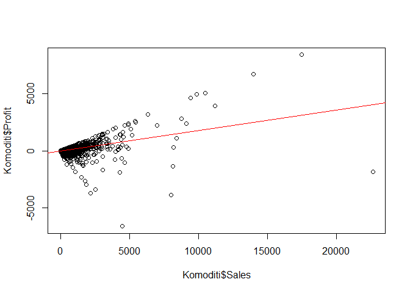

```r
plot(Komoditi$Sales,Komoditi$Profit)
abline(lm(Komoditi$Profit~Komoditi$Sales),col='red')
```

```r
cor(Komoditi$Sales,Komoditi$Quantity)
```

```
## [1] 0.2007948
```

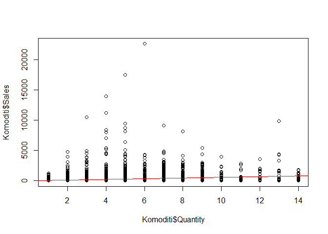

```r
plot(Komoditi$Quantity,Komoditi$Sales)
abline(lm(Komoditi$Sales~Komoditi$Quantity),col='red')
```

```r
cor(Komoditi$Profit,Komoditi$Quantity)
```

```
## [1] 0.06625319
```

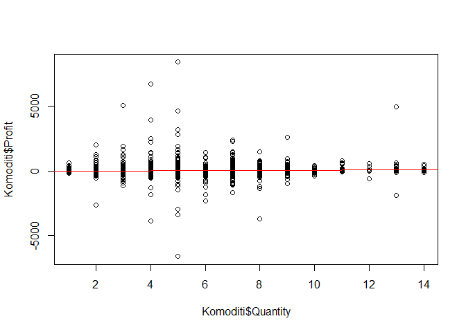

```r
plot(Komoditi$Quantity,Komoditi$Profit)
abline(lm(Komoditi$Profit~Komoditi$Quantity),col='red')
```

```r
cor(Komoditi$Discount,Komoditi$Sales)
```

```
## [1] -0.02819012
```

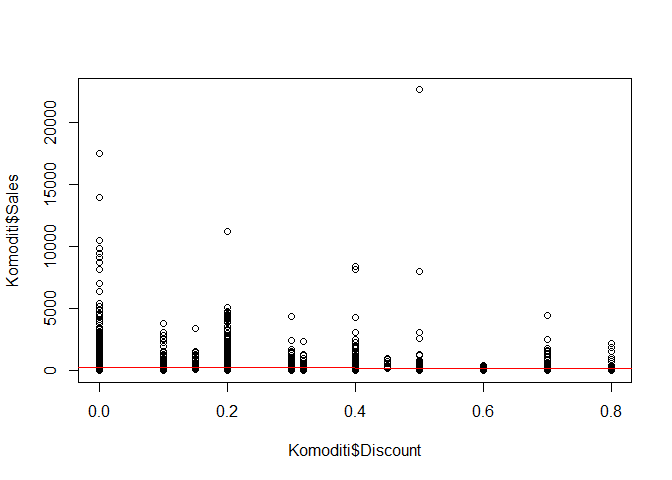

```r
plot(Komoditi$Discount,Komoditi$Sales)
abline(lm(Komoditi$Sales~Komoditi$Discount),col='red')
```

```r
cor(Komoditi$Discount,Komoditi$Profit)
```

```
## [1] -0.2194875
```

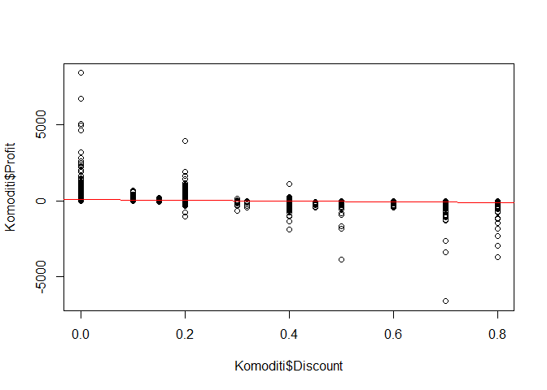

```r
plot(Komoditi$Discount,Komoditi$Profit)
abline(lm(Komoditi$Profit~Komoditi$Discount),col='red')
```

```r
cor(Komoditi$Discount,Komoditi$Profit)
```

```
## [1] -0.2194875
```

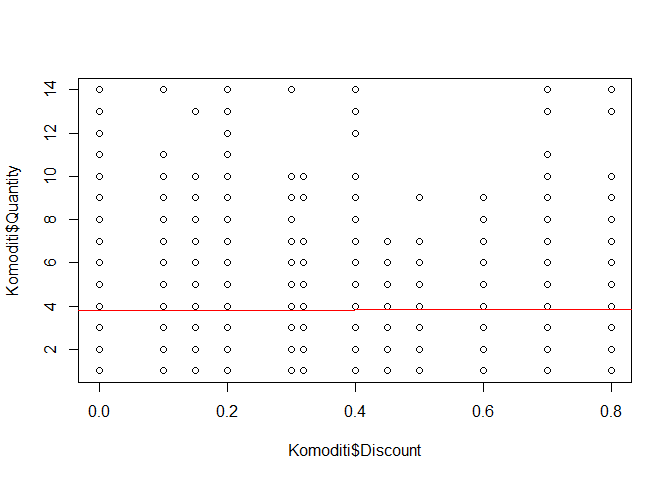

```r
plot(Komoditi$Discount,Komoditi$Quantity)
abline(lm(Komoditi$Quantity~Komoditi$Discount),col='red')
```

# 4. Analysis

Now we will do analysis to some business questions related to this data.

1. Which Ship Mode that have provided the lowest and the highest sum of Sales,Profit & Quantity.

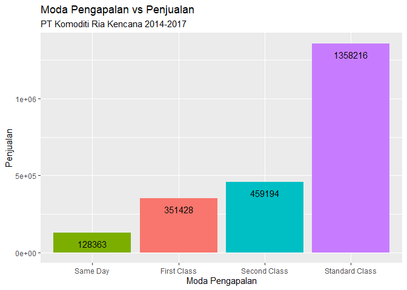

```r
library(ggplot2)
komss <- aggregate.data.frame(x=list(komoditi$Sales,komoditi$Profit,komoditi$Quantity),
                                     by=list(komoditi$Ship.Mode),FUN=sum)
komss <- setNames(komss,c("Moda_Pengapalan","Penjualan","Keuntungan","Kuantiti"))

ggplot(data=komss,mapping=aes(x=reorder(Moda_Pengapalan,Penjualan),
                              y=Penjualan,fill=Moda_Pengapalan))+
  geom_col(show.legend = F)+
  geom_text(aes(label=round(Penjualan,0)),vjust=2)+
  labs(title="Moda Pengapalan vs Penjualan",
       subtitle="PT Komoditi Ria Kencana 2014-2017",
       x="Moda Pengapalan",
       y="Penjualan")
```

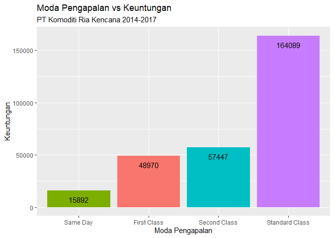

```r
ggplot(data=komss,mapping=aes(x=reorder(Moda_Pengapalan,Keuntungan),
                              y=Keuntungan,fill=Moda_Pengapalan))+
  geom_col(show.legend = F)+
  geom_text(aes(label=round(Keuntungan,0)),vjust=2)+
  labs(title="Moda Pengapalan vs Keuntungan",
       subtitle="PT Komoditi Ria Kencana 2014-2017",
       x="Moda Pengapalan",
       y="Keuntungan")
```

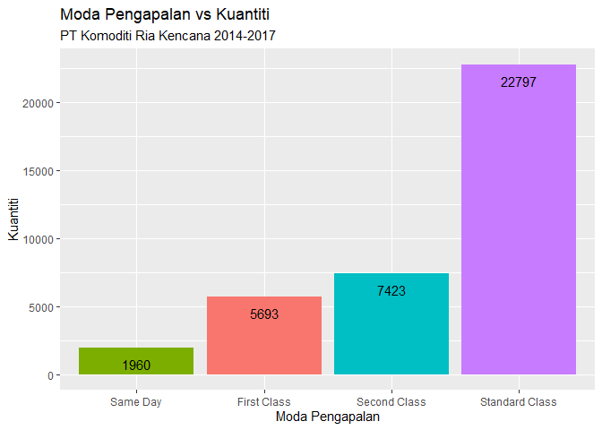

```r
ggplot(data=komss,mapping=aes(x=reorder(Moda_Pengapalan,Kuantiti),
                              y=Kuantiti,fill=Moda_Pengapalan))+
  geom_col(show.legend = F)+
  geom_text(aes(label=Kuantiti),vjust=2)+
  labs(title="Moda Pengapalan vs Kuantiti",
       subtitle="PT Komoditi Ria Kencana 2014-2017",
       x="Moda Pengapalan",
       y="Kuantiti")
```

If we look at the plots above, we can analyse that in terms of Total Sales, Total Profit, and Total Quantity, most of buyers choose Standard Class as the shipping mode option while Same Day shipping mode option is the least favourite.

2. Which Segment that have provided the lowest and the highest sum of Sales,Profit & Quantity.

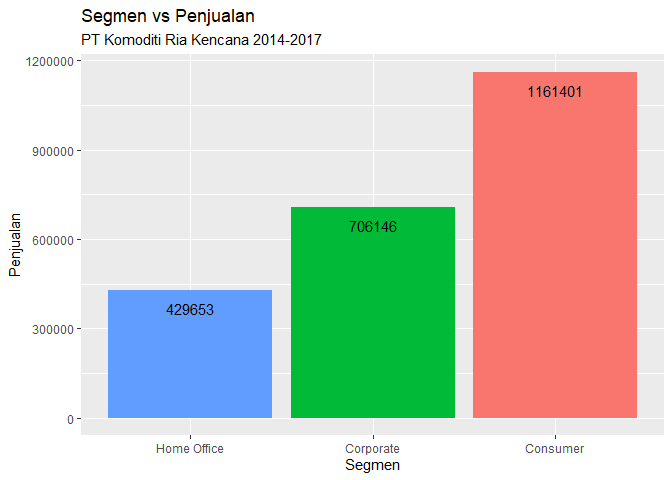

```r
komseg <- aggregate.data.frame(x=list(komoditi$Sales,komoditi$Profit,komoditi$Quantity),
                                     by=list(komoditi$Segment),FUN=sum)
komseg <- setNames(komseg,c("Segmen","Penjualan","Keuntungan","Kuantiti"))


ggplot(data=komseg,mapping=aes(x=reorder(Segmen,Penjualan),
                              y=Penjualan,fill=Segmen))+
  geom_col(show.legend = F)+
  geom_text(aes(label=round(Penjualan,0)),vjust=2)+
  labs(title="Segmen vs Penjualan",
       subtitle="PT Komoditi Ria Kencana 2014-2017",
       x="Segmen",
       y="Penjualan")
```

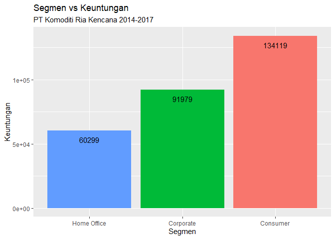

```r
ggplot(data=komseg,mapping=aes(x=reorder(Segmen,Keuntungan),
                              y=Keuntungan,fill=Segmen))+
  geom_col(show.legend = F)+
  geom_text(aes(label=round(Keuntungan,0)),vjust=2)+
  labs(title="Segmen vs Keuntungan",
       subtitle="PT Komoditi Ria Kencana 2014-2017",
       x="Segmen",
       y="Keuntungan")
```

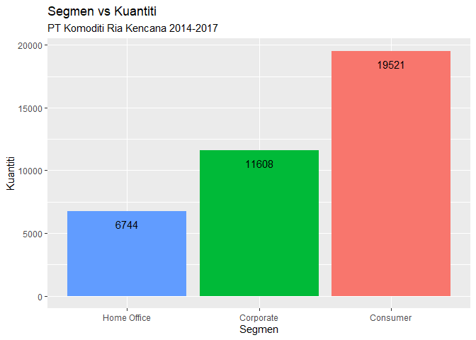

```r
ggplot(data=komseg,mapping=aes(x=reorder(Segmen,Kuantiti),
                              y=Kuantiti,fill=Segmen))+
  geom_col(show.legend = F)+
  geom_text(aes(label=round(Kuantiti,0)),vjust=2)+
  labs(title="Segmen vs Kuantiti",
       subtitle="PT Komoditi Ria Kencana 2014-2017",
       x="Segmen",
       y="Kuantiti")
```

If we look at the plots above, we can analyse that in terms of Total Sales, Total Profit, and Total Quantity, most of buyers choose to buy products in Consumer Segment while products from Home Office Segment is the least favourite.

3. Which Category products that have provided the lowest and the highest sum of Sales,Profit & Quantity

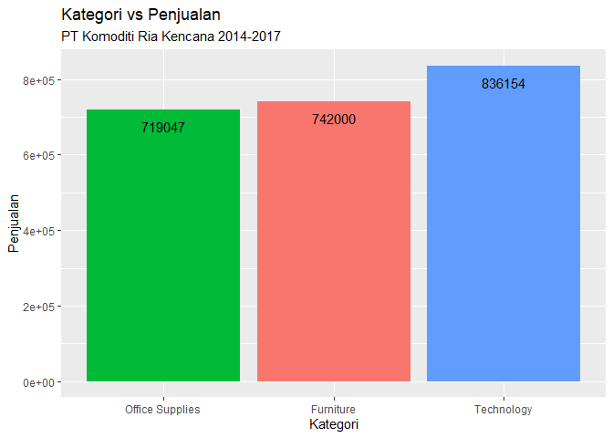

```r
komcat <- aggregate.data.frame(x=list(komoditi$Sales,komoditi$Profit,komoditi$Quantity),
                                     by=list(komoditi$Category),FUN=sum)
komcat <- setNames(komcat,c("Kategori","Penjualan","Keuntungan","Kuantiti"))


ggplot(data=komcat,mapping=aes(x=reorder(Kategori,Penjualan),
                              y=Penjualan,fill=Kategori))+
  geom_col(show.legend = F)+
  geom_text(aes(label=round(Penjualan,0)),vjust=2)+
  labs(title="Kategori vs Penjualan",
       subtitle="PT Komoditi Ria Kencana 2014-2017",
       x="Kategori",
       y="Penjualan")
```

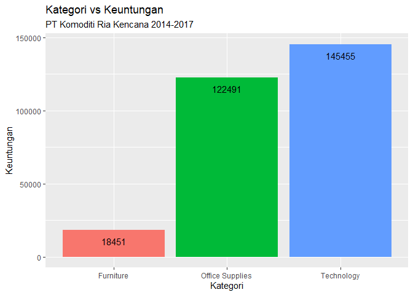

```r
ggplot(data=komcat,mapping=aes(x=reorder(Kategori,Keuntungan),
                              y=Keuntungan,fill=Kategori))+
  geom_col(show.legend = F)+
  geom_text(aes(label=round(Keuntungan,0)),vjust=2)+
  labs(title="Kategori vs Keuntungan",
       subtitle="PT Komoditi Ria Kencana 2014-2017",
       x="Kategori",
       y="Keuntungan")
```

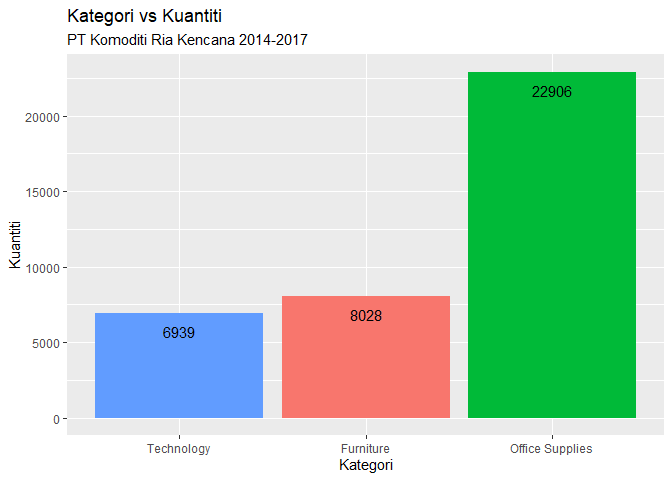

```r
ggplot(data=komcat,mapping=aes(x=reorder(Kategori,Kuantiti),
                              y=Kuantiti,fill=Kategori))+
  geom_col(show.legend = F)+
  geom_text(aes(label=round(Kuantiti,0)),vjust=2)+
  labs(title="Kategori vs Kuantiti",
       subtitle="PT Komoditi Ria Kencana 2014-2017",
       x="Kategori",
       y="Kuantiti")
```

4. Which Sub-Category products that have provided the lowest and the highest sum of Sales,Profit & Quantity

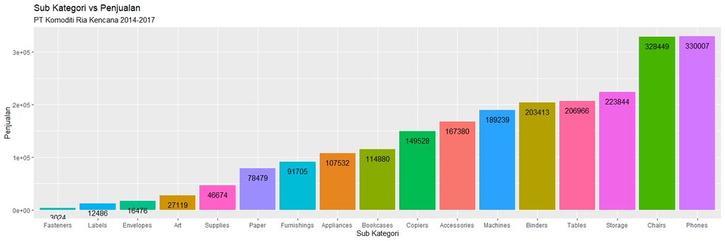

```r
komsub <- aggregate.data.frame(x=list(komoditi$Sales,komoditi$Profit,komoditi$Quantity),
                                     by=list(komoditi$Sub.Category),FUN=sum)
komsub <- setNames(komsub,c("Sub_Kategori","Penjualan","Keuntungan","Kuantiti"))

ggplot(data=komsub,mapping=aes(x=reorder(Sub_Kategori,Penjualan),
                              y=Penjualan,fill=Sub_Kategori))+
  geom_col(show.legend = F)+
  geom_text(aes(label=round(Penjualan,0)),vjust=2)+
  labs(title="Sub Kategori vs Penjualan",
       subtitle="PT Komoditi Ria Kencana 2014-2017",
       x="Sub Kategori",
       y="Penjualan")
```

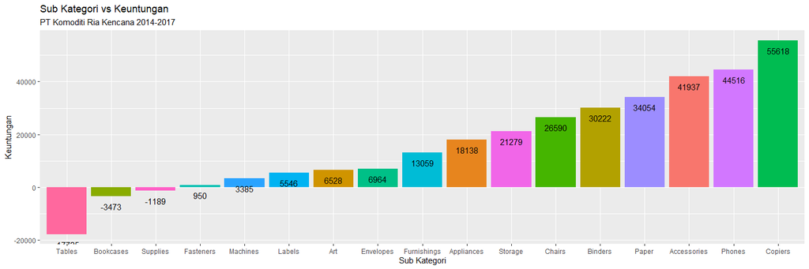

```r
komsub <- aggregate.data.frame(x=list(komoditi$Sales,komoditi$Profit,komoditi$Quantity),
                                     by=list(komoditi$Sub.Category),FUN=sum)
komsub <- setNames(komsub,c("Sub_Kategori","Penjualan","Keuntungan","Kuantiti"))

ggplot(data=komsub,mapping=aes(x=reorder(Sub_Kategori,Keuntungan),
                              y=Keuntungan,fill=Sub_Kategori))+
  geom_col(show.legend = F)+
  geom_text(aes(label=round(Keuntungan,0)),vjust=2)+
  labs(title="Sub Kategori vs Keuntungan",
       subtitle="PT Komoditi Ria Kencana 2014-2017",
       x="Sub Kategori",
       y="Keuntungan")
```

```r
#There are products with negative profit. Now check the detail discount from these products

loss <- subset(komoditi,subset=komoditi$Sub.Category=="Tables"|
           komoditi$Sub.Category=="Bookcases"|
           komoditi$Sub.Category=="Supplies")
aggregate(loss$Discount~loss$Sub.Category+loss$Category+loss$Segment,FUN=mean)
```

| loss$Sub.Category | loss$Category | loss$Segment | loss$Discount |
| --- | --- | --- | --- |
| Bookcases | Furniture | Consumer | 0.22145038 |
| Tables | Furniture | Consumer | 0.26603774 |
| Supplies | Office Supplies | Consumer | 0.09000000 |
| Bookcases | Furniture | Corporate | 0.21875000 |
| Tables | Furniture | Corporate | 0.25990566 |
| Supplies | Office Supplies | Corporate | 0.06229508 |
| Bookcases | Furniture | Home Office | 0.15545455 |
| Tables | Furniture | Home Office | 0.25000000 |
| Supplies | Office Supplies | Home Office | 0.06206897 |

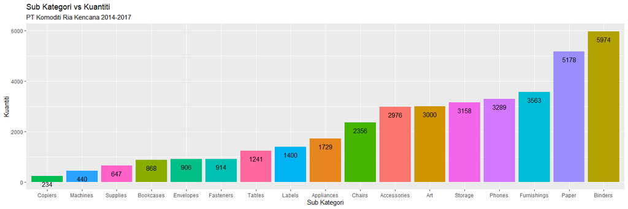

```r
komsub <- aggregate.data.frame(x=list(komoditi$Sales,komoditi$Profit,komoditi$Quantity),
                                     by=list(komoditi$Sub.Category),FUN=sum)
komsub <- setNames(komsub,c("Sub_Kategori","Penjualan","Keuntungan","Kuantiti"))

ggplot(data=komsub,mapping=aes(x=reorder(Sub_Kategori,Kuantiti),
                              y=Kuantiti,fill=Sub_Kategori))+
  geom_col(show.legend = F)+
  geom_text(aes(label=round(Kuantiti,0)),vjust=2)+
  labs(title="Sub Kategori vs Kuantiti",
       subtitle="PT Komoditi Ria Kencana 2014-2017",
       x="Sub Kategori",
       y="Kuantiti")
```

If we look at the plots above, we can analyse as belows:

- In terms of Total Sales, Phones sub-category products provide the highest while Fasteners sub-category products provide the least
- In terms of Profitablity, Copiers sub-category products provide the highest profit. We found that some sub-category product happened to be negative profit. These sub-category are Tables, Bookcases and Supplies.
- In terms of Quantity, Binders sub-category products provide the highest while Copiers sub-category products provide the least
- Copiers products provides the most profitability with the least quantity compare to others.

# 5. Business Recommendation

PT Komoditi Ria kencana has been doing business since 2014. We have analysed all the commercial transaction from 2014-2017 specifically in products. We come with below recommendation for better future business:

- Standard Class Ship mode is the most preferred by buyers. PT Komoditi should keep this ship mode options since this ship mode provides the most sales, profitability and quantity. Please consider to delete Same-Day ship and ask buyers to move to First Class ship mode since First Class ship Mode provide the better sales, profitablility annd quantity compare to Same-Day ship mode.
- PT Komoditi do not need to change all the products Segments since all Segments provides positive sales, profit, and quantity.
- PT Komoditi do not need to change all the products Category since all Category provides positive sales, profit, and quantity.However there are some things that PT Komoditi needs to be considered. In Furniture Category, Although the sales is positively high, the profitability and the quantity sold is considerably low. PT Komoditi should consider to source these products from another vendors with lesser price or lower the discount.
- During Analysis of the sub-category products, we found that there are several products that cause negative profit (Bookcases, Tables, and Supplies). Please consider to lower the discount this sub-category products or source these products from another vendors with lesser price. We can consider also to delete “supplies” sub-category product since the sales is low, the quantity is low, negative profit with almost zero discount.
- PT Komoditi needs to sell more “Copiers” since this products provide the highest profitability with the least quantity. Please consider to give a little bit more discount to grow the quantity, sales, and profitability.